# Project: Investigate a Dataset (European Soccer)

- Introduction
- Data Wrangling
- Exploratory Data Analysis
- Conclusions

## Introduction

To complete my Data Analysis project I will be using the European Soccer Database.

This database is a collection of 7 different tablels. It contains data of around 25,000 matches, about 10,000 players, 11 different countries with their lead championship, seasons 2008-2016, player and team attributes from the EA Sports FIFA video game, betting odds and detail of match events.

Here are the different questions I asked:

- Which team factors correlate most with best goal differential?
- Which team factors correlate most with most wins?
- Which teams were the best overall (season, team)?
- Which teams have been the best and worst consistently?

```python
# Use this cell to set up import statements for all of the packages that you
#   plan to use.

# Remember to include a 'magic word' so that your visualizations are plotted
#   inline with the notebook. See this page for more:
#   http://ipython.readthedocs.io/en/stable/interactive/magics.html

import sqlite3
import pandas as pd
import numpy as np
from datetime import datetime
import matplotlib.pyplot as plt
%matplotlib inline
%config InlineBackend.figure_format = 'retina'

cnx = sqlite3.connect('database.sqlite')
team = pd.read_sql_query("SELECT team_api_id, team_long_name as team FROM Team", cnx)
match = pd.read_sql_query("SELECT * FROM Match", cnx)
team_attr = pd.read_sql_query("SELECT * FROM Team_Attributes", cnx)
```

## Data Wrangling

> **Tip**: In this section of the report, you will load in the data, check for cleanliness, and then trim and clean your dataset for analysis. Make sure that you document your steps carefully and justify your cleaning decisions.

### General Properties

```python
#checked the columns of team
team.info()
```

```
<class 'pandas.core.frame.DataFrame'>
RangeIndex: 299 entries, 0 to 298
Data columns (total 2 columns):
 #   Column       Non-Null Count  Dtype
---  ------       --------------  -----
 0   team_api_id  299 non-null    int64
 1   team         299 non-null    object
dtypes: int64(1), object(1)
memory usage: 4.8+ KB
```

```python
#wanted to understand the team_attr table
#spotted one column with a bunch of nulls while all the other columns were fine
#also noticed that season was not added but data was -
#changed date column and column in the match dataframe so that both matched
team_attr.info()
```

```
<class 'pandas.core.frame.DataFrame'>
RangeIndex: 1458 entries, 0 to 1457
Data columns (total 25 columns):
 #   Column                          Non-Null Count  Dtype
---  ------                          --------------  -----
 0   id                              1458 non-null   int64
 1   team_fifa_api_id                1458 non-null   int64
 2   team_api_id                     1458 non-null   int64
 3   date                            1458 non-null   object
 4   buildUpPlaySpeed                1458 non-null   int64
 5   buildUpPlaySpeedClass           1458 non-null   object
 6   buildUpPlayDribbling            489 non-null    float64
 7   buildUpPlayDribblingClass       1458 non-null   object
 8   buildUpPlayPassing              1458 non-null   int64
 9   buildUpPlayPassingClass         1458 non-null   object
```

[output cut: 17 more lines]

```python
#only 1 column with NA's and have lots so drop that column
team_attr.drop(columns=['buildUpPlayDribbling'], inplace=True)
```

### Data Cleaning

I began by making the match dataframe into a more of a season statistics dataset using aggregate by-season/team. I performed further cleaning on the match dataframe and added my own season statistics.

The team attributes already is aggregated by season and team, so I basically did some cleaing on it. Then I merged the 2 datasets in to one big dataset, which I performed exploratory analysis on.

The only place we can see teams is home team and away team columns. In order to make calculations easier, I aggregated the dataframe by home team and season. Then I aggregated once again on away team and season. I will later combine the home dataframe and the away dataframe for further analysis.

```python
#matched data so that it would match team_attr dataframe
match['date'] = match['season'].str.slice_replace(start=4, repl='')
#incorporated the team dataframe into match dataframe because team only has 2 columns
team_dict = dict(zip(team['team_api_id'], team['team']))
match['home_team'] = [ team_dict[id_] for id_ in match['home_team_api_id'] ]
match['away_team'] = [ team_dict[id_] for id_ in match['away_team_api_id'] ]
#Created 3 different columns to represent win, ties and loses
match['home_win'] = (match['home_team_goal'] >  match['away_team_goal'])
match['tie'] = (match['home_team_goal'] ==  match['away_team_goal'])
match['away_win'] = (match['home_team_goal'] <  match['away_team_goal'])
#crated 2 dataframes with home matchs and away matches, both with same set of columns
home_match = match[['date', 'home_team', 'home_win', 'tie', 'away_win', 'home_team_goal', 'away_team_goal']]
home_match.columns = ['date', 'team', 'wins', 'ties', 'loses', 'goals_scored', 'goals_given']
away_match = match[['date', 'away_team', 'away_win', 'tie', 'home_win', 'away_team_goal', 'home_team_goal']]
away_match.columns = home_match.columns
#get aggregated statistics of home and away matches
home_match = home_match.groupby(by=["team", 'date'], as_index=False).sum()
away_match = away_match.groupby(by=["team", 'date'], as_index=False).sum()
home_match.shape, away_match.shape
```

```
((1478, 7), (1478, 7))
```

Here I merged the home and away dataframe. Following the merge, I created my own columns showing statistics that were not displayed earlier.

```python
df = home_match.merge(away_match, on=["team", 'date'])
new_labels = []
for col in df.columns:
    if '_x' in col:
        new_labels.append('home_' + col[:-2])
    elif '_y' in col:
        new_labels.append('away_' + col[:-2])
    else :
        new_labels.append(col)
df.columns = new_labels
df['wins'] = df['home_wins'] + df['away_wins']
df['loses'] = df['home_loses'] + df['away_loses']
df['ties'] = df['home_ties'] + df['away_ties']
df['goals_differential'] = (df['home_goals_scored'] + df['away_goals_scored']) / (df['home_goals_given'] + df['away_goals_given'])

df['games'] = (df['wins'] + df['loses'] + df['ties'])
df['win_pct'] = df['wins'] / df['games']
df['loss_pct'] = df['loses'] / df['games']
df['ties_pct'] = df['ties'] / df['games']
df.head()
```

|  | team | date | home_wins | home_ties | home_loses | home_goals_scored | home_goals_given | away_wins | away_ties | away_loses | away_goals_scored | away_goals_given | wins | loses | ties | goals_differential | games | win_pct | loss_pct | ties_pct |
| --- | --- | --- | --- | --- | --- | --- | --- | --- | --- | --- | --- | --- | --- | --- | --- | --- | --- | --- | --- | --- |
| 0 | 1. FC Kaiserslautern | 2010 | 6 | 6 | 5 | 25 | 19 | 7 | 1 | 9 | 23 | 32 | 13 | 14 | 7 | 0.941176 | 34 | 0.382353 | 0.411765 | 0.205882 |
| 1 | 1. FC Kaiserslautern | 2011 | 2 | 5 | 10 | 12 | 28 | 2 | 6 | 9 | 12 | 26 | 4 | 19 | 11 | 0.444444 | 34 | 0.117647 | 0.558824 | 0.323529 |
| 2 | 1. FC Köln | 2008 | 4 | 5 | 8 | 14 | 25 | 7 | 1 | 9 | 21 | 25 | 11 | 17 | 6 | 0.700000 | 34 | 0.323529 | 0.500000 | 0.176471 |
| 3 | 1. FC Köln | 2009 | 3 | 6 | 8 | 18 | 29 | 6 | 5 | 6 | 15 | 13 | 9 | 14 | 11 | 0.785714 | 34 | 0.264706 | 0.411765 | 0.323529 |
| 4 | 1. FC Köln | 2010 | 11 | 2 | 4 | 30 | 21 | 2 | 3 | 12 | 17 | 41 | 13 | 16 | 5 | 0.758065 | 34 | 0.382353 | 0.470588 | 0.147059 |

This concluded my handling with the match dataframe. I moved on to the team_attr dataframe. I began by cleaning up the columns to match. First I matched the date column in team_attr with the date column in the other dataframe. Following that instead of having the team code I changed it to the team name. Then I tried to gain info on the data types. I already know from previously that there are no NA's.

```python
#adjust the date and add team_name
team_attr['date'] = [d[:4] for d in team_attr['date']]
team_attr['team'] = [ team_dict[id_] for id_ in team_attr['team_api_id'] ]
#check the data types
team_attr.info()
```

```
<class 'pandas.core.frame.DataFrame'>
RangeIndex: 1458 entries, 0 to 1457
Data columns (total 25 columns):
 #   Column                          Non-Null Count  Dtype
---  ------                          --------------  -----
 0   id                              1458 non-null   int64
 1   team_fifa_api_id                1458 non-null   int64
 2   team_api_id                     1458 non-null   int64
 3   date                            1458 non-null   object
 4   buildUpPlaySpeed                1458 non-null   int64
 5   buildUpPlaySpeedClass           1458 non-null   object
 6   buildUpPlayDribblingClass       1458 non-null   object
 7   buildUpPlayPassing              1458 non-null   int64
 8   buildUpPlayPassingClass         1458 non-null   object
 9   buildUpPlayPositioningClass     1458 non-null   object
```

[output cut: 17 more lines]

In order to deal with the non-numeric columns I check their cardinality. It seems that no columns have a high cardinality, so if we convert to dummies it won't blow up the number of columns

```python
#check how many unique value each string has
#since no column has high cardinality it was cool to just make the string columns into dummy columns
team_attr.select_dtypes(include=object).drop(columns=['date', 'team']).nunique()
```

```
buildUpPlaySpeedClass             3
buildUpPlayDribblingClass         3
buildUpPlayPassingClass           3
buildUpPlayPositioningClass       2
chanceCreationPassingClass        3
chanceCreationCrossingClass       3
chanceCreationShootingClass       3
chanceCreationPositioningClass    2
defencePressureClass              3
defenceAggressionClass            3
defenceTeamWidthClass             3
defenceDefenderLineClass          2
dtype: int64
```

I replaced the string columns with dummy columns to avoid categorical columns.

```python
#convert all the string columns to dummy columns
t = team_attr.copy()
team_attr_str = t.select_dtypes(include=object).drop(columns=['date', 'team'])
t.drop(columns=team_attr_str.columns, inplace=True)
team_attr_str = pd.get_dummies(team_attr_str, dummy_na=False)
team_attr = pd.concat([t, team_attr_str], axis=1)
team_attr.head()
```

|  | id | team_fifa_api_id | team_api_id | date | buildUpPlaySpeed | buildUpPlayPassing | chanceCreationPassing | chanceCreationCrossing | chanceCreationShooting | defencePressure | ... | defencePressureClass_High | defencePressureClass_Medium | defenceAggressionClass_Contain | defenceAggressionClass_Double | defenceAggressionClass_Press | defenceTeamWidthClass_Narrow | defenceTeamWidthClass_Normal | defenceTeamWidthClass_Wide | defenceDefenderLineClass_Cover | defenceDefenderLineClass_Offside Trap |
| --- | --- | --- | --- | --- | --- | --- | --- | --- | --- | --- | --- | --- | --- | --- | --- | --- | --- | --- | --- | --- | --- |
| 0 | 1 | 434 | 9930 | 2010 | 60 | 50 | 60 | 65 | 55 | 50 | ... | 0 | 1 | 0 | 0 | 1 | 0 | 1 | 0 | 1 | 0 |
| 1 | 2 | 434 | 9930 | 2014 | 52 | 56 | 54 | 63 | 64 | 47 | ... | 0 | 1 | 0 | 0 | 1 | 0 | 1 | 0 | 1 | 0 |
| 2 | 3 | 434 | 9930 | 2015 | 47 | 54 | 54 | 63 | 64 | 47 | ... | 0 | 1 | 0 | 0 | 1 | 0 | 1 | 0 | 1 | 0 |
| 3 | 4 | 77 | 8485 | 2010 | 70 | 70 | 70 | 70 | 70 | 60 | ... | 0 | 1 | 0 | 1 | 0 | 0 | 0 | 1 | 1 | 0 |
| 4 | 5 | 77 | 8485 | 2011 | 47 | 52 | 53 | 48 | 52 | 47 | ... | 0 | 1 | 0 | 0 | 1 | 0 | 1 | 0 | 1 | 0 |

5 rows × 46 columns

I merged the 2 dataframes and removed a couple unnecessary columns.

```python
#group team_attr by team and the date to signify the season
team_attr = team_attr.groupby(['team', 'date'], as_index=False).mean()
#merge all the dataframes for one final dataframe
df = df.merge(team_attr, on=['team', 'date'])
#drop all the unimportant columns

df.drop(columns=['home_wins', 'home_ties', 'home_loses',
       'home_goals_scored', 'home_goals_given', 'away_wins', 'away_ties',
       'away_loses', 'away_goals_scored', 'away_goals_given', 'wins', 'loses',
       'ties', 'games', 'id', 'team_fifa_api_id', 'team_api_id'], inplace=True)
df.head()
```

|  | team | date | goals_differential | win_pct | loss_pct | ties_pct | buildUpPlaySpeed | buildUpPlayPassing | chanceCreationPassing | chanceCreationCrossing | ... | defencePressureClass_High | defencePressureClass_Medium | defenceAggressionClass_Contain | defenceAggressionClass_Double | defenceAggressionClass_Press | defenceTeamWidthClass_Narrow | defenceTeamWidthClass_Normal | defenceTeamWidthClass_Wide | defenceDefenderLineClass_Cover | defenceDefenderLineClass_Offside Trap |
| --- | --- | --- | --- | --- | --- | --- | --- | --- | --- | --- | --- | --- | --- | --- | --- | --- | --- | --- | --- | --- | --- |
| 0 | 1. FC Kaiserslautern | 2010 | 0.941176 | 0.382353 | 0.411765 | 0.205882 | 45.0 | 55.0 | 45.0 | 70.0 | ... | 1 | 0 | 0 | 1 | 0 | 0 | 0 | 1 | 1 | 0 |
| 1 | 1. FC Kaiserslautern | 2011 | 0.444444 | 0.117647 | 0.558824 | 0.323529 | 48.0 | 42.0 | 49.0 | 68.0 | ... | 0 | 1 | 0 | 0 | 1 | 0 | 1 | 0 | 1 | 0 |
| 2 | 1. FC Köln | 2010 | 0.758065 | 0.382353 | 0.470588 | 0.147059 | 55.0 | 65.0 | 65.0 | 40.0 | ... | 0 | 1 | 0 | 0 | 1 | 0 | 0 | 1 | 1 | 0 |
| 3 | 1. FC Köln | 2011 | 0.520000 | 0.235294 | 0.588235 | 0.176471 | 58.0 | 71.0 | 42.0 | 39.0 | ... | 0 | 1 | 0 | 0 | 1 | 0 | 1 | 0 | 1 | 0 |
| 4 | 1. FC Köln | 2014 | 0.850000 | 0.264706 | 0.352941 | 0.382353 | 59.0 | 57.0 | 53.0 | 47.0 | ... | 0 | 1 | 0 | 0 | 1 | 0 | 1 | 0 | 1 | 0 |

5 rows × 47 columns

```python
#as we can see no null values so this is good
df.isna().sum()
```

```
team                                        0
date                                        0
goals_differential                          0
win_pct                                     0
loss_pct                                    0
ties_pct                                    0
buildUpPlaySpeed                            0
buildUpPlayPassing                          0
chanceCreationPassing                       0
chanceCreationCrossing                      0
chanceCreationShooting                      0
defencePressure                             0
defenceAggression                           0
defenceTeamWidth                            0
buildUpPlaySpeedClass_Balanced              0
buildUpPlaySpeedClass_Fast                  0
buildUpPlaySpeedClass_Slow                  0
buildUpPlayDribblingClass_Little            0
buildUpPlayDribblingClass_Lots              0
buildUpPlayDribblingClass_Normal            0
buildUpPlayPassingClass_Long                0
buildUpPlayPassingClass_Mixed               0
buildUpPlayPassingClass_Short               0
buildUpPlayPositioningClass_Free Form       0
buildUpPlayPositioningClass_Organised       0
chanceCreationPassingClass_Normal           0
chanceCreationPassingClass_Risky            0
chanceCreationPassingClass_Safe             0
chanceCreationCrossingClass_Little          0
chanceCreationCrossingClass_Lots            0
chanceCreationCrossingClass_Normal          0
chanceCreationShootingClass_Little          0
chanceCreationShootingClass_Lots            0
chanceCreationShootingClass_Normal          0
chanceCreationPositioningClass_Free Form    0
chanceCreationPositioningClass_Organised    0
defencePressureClass_Deep                   0
defencePressureClass_High                   0
defencePressureClass_Medium                 0
defenceAggressionClass_Contain              0
defenceAggressionClass_Double               0
defenceAggressionClass_Press                0
defenceTeamWidthClass_Narrow                0
defenceTeamWidthClass_Normal                0
defenceTeamWidthClass_Wide                  0
defenceDefenderLineClass_Cover              0
defenceDefenderLineClass_Offside Trap       0
dtype: int64
```

## Exploratory Data Analysis

Before I delved into any of my research questions, I knew this correlation matrix would come i handy for 2 of my research questions. So I computed it beforehand.

```python
#we will use this correlation matrix for the 2 research questions
corr_mat = df.corr()[['goals_differential', 'win_pct', 'loss_pct', 'ties_pct']].iloc[6:]
corr_mat.head()
```

|  | goals_differential | win_pct | loss_pct | ties_pct |
| --- | --- | --- | --- | --- |
| chanceCreationPassing | 0.055496 | 0.070079 | -0.064196 | -0.022725 |
| chanceCreationCrossing | 0.016406 | 0.036464 | -0.043554 | 0.005847 |
| chanceCreationShooting | 0.079780 | 0.087565 | -0.070452 | -0.045391 |
| defencePressure | 0.223395 | 0.217931 | -0.187335 | -0.092085 |
| defenceAggression | 0.103183 | 0.116618 | -0.099911 | -0.049859 |

### Research Question 1: Which factors correlate with best goals differential?

To check which factors affected the goal differential, I used the pre-computed cor_mat with all the correlation coefficient.

Here I show 4 most correlated rows and the 4 least correlated rows.

```python
# Use this, and more code cells, to explore your data. Don't forget to add
#   Markdown cells to document your observations and findings.
corr_mat[['goals_differential']].sort_values(by=['goals_differential'], ascending=False).iloc[np.r_[0:4, -4:0]]
```

|  | goals_differential |
| --- | --- |
| chanceCreationPositioningClass_Free Form | 0.274834 |
| buildUpPlayPositioningClass_Free Form | 0.226230 |
| defencePressure | 0.223395 |
| chanceCreationShootingClass_Lots | 0.160027 |
| buildUpPlayPassingClass_Long | -0.092307 |
| chanceCreationShootingClass_Normal | -0.170588 |
| buildUpPlayPositioningClass_Organised | -0.226230 |
| chanceCreationPositioningClass_Organised | -0.274834 |

It seems like whether the Buildup Play Position and Chance Creation Positioning was free-form or organized had the biggest impact on the goal differential. To account for teams that played more or less games, I used **goal differential** which was the ratio (goals scored/goals given).

Here I showed a box-plot of the 4 different situaions. The blue line going across the middle is the mean goal differential. As we can see Free Form's mean is above the total mean, while Organized is below for both. **Organized vs free-form creation positioning** means that that in any given time how much freedom people have the flexibility to stray from positions to support other positions on offense (meaning the "third pitch" of the field. **Organized vs free-form build-play-position** is similar in that it indicates people's flexibility to stray from their position in the "first two pitches" of the field meaning around midfield.

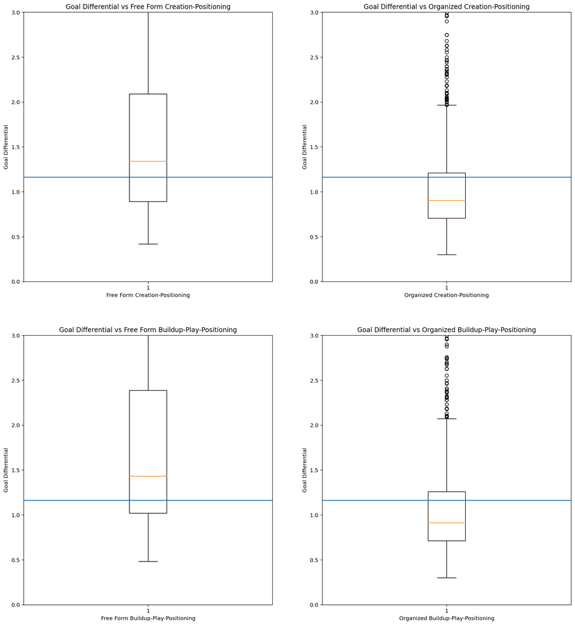

```python
import matplotlib.pyplot as plt
cols = ['chanceCreationPositioningClass_Free Form', 'chanceCreationPositioningClass_Organised',
        'buildUpPlayPositioningClass_Free Form', 'buildUpPlayPositioningClass_Organised']
labels = ['Free Form Creation-Positioning', 'Organized Creation-Positioning',
          'Free Form Buildup-Play-Positioning', 'Organized Buildup-Play-Positioning']
factor = 'goals_differential'
ylab = 'Goal Differential'
ylim = 3
def boxplot_() :
    fig = plt.figure(figsize=(18, 20))
    i = 1
    m = df[factor].mean()
    for col in cols :
        x = df[ df[col] == 1 ][[factor]]
        ax = plt.subplot(2, 2, i);
        ax.boxplot(x[factor]);
        plt.ylim(0, ylim);
        ax.set_xlabel(labels[i - 1])
        ax.set_ylabel(ylab)
        ax.set_title(ylab +' vs ' + labels[i - 1]);
        plt.axhline(y=m)
        i += 1
boxplot_()
```

As indicated by the 4 boxplots for free-form for both creation-position and build-up position was mostly above the blue line which was the mean goal differential.

On the other hand, the distribution for organized for both creation-position and build-up position was mostly below the blue line which was the mean goal differential.

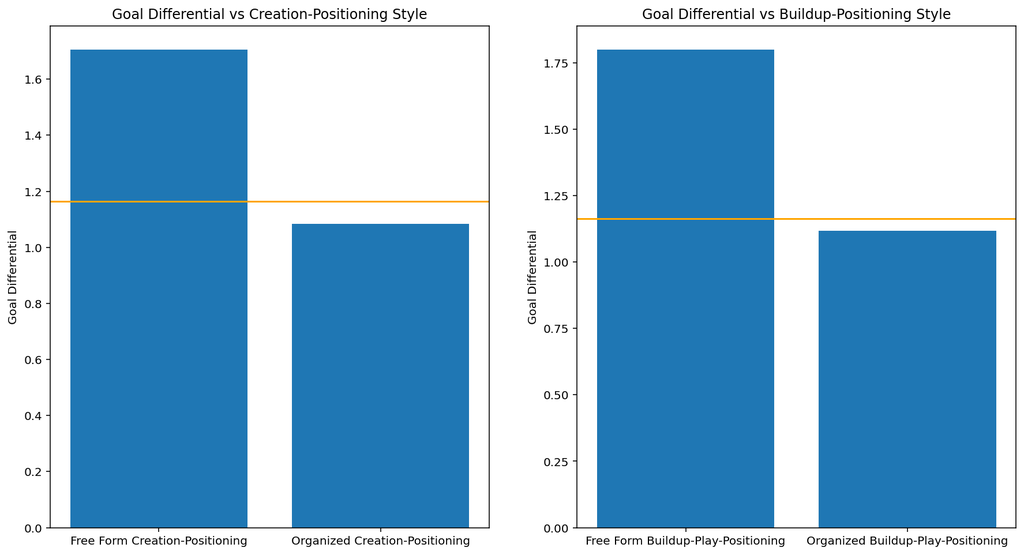

```python
ylab = 'Goal Differential'
factor = 'goals_differential'

def barplot_() :
    df_temp = df[['chanceCreationPositioningClass_Free Form', 'chanceCreationPositioningClass_Organised',
                  'buildUpPlayPositioningClass_Free Form', 'buildUpPlayPositioningClass_Organised', factor]]

    create_free = df_temp[df_temp["chanceCreationPositioningClass_Free Form"] == 1][factor].mean()
    create_organized = df_temp[df_temp["chanceCreationPositioningClass_Organised"] == 1][factor].mean()
    build_free = df_temp[df_temp['buildUpPlayPositioningClass_Free Form'] == 1][factor].mean()
    build_organized = df_temp[df_temp['buildUpPlayPositioningClass_Organised'] == 1][factor].mean()


    m = df[factor].mean()
    fig = plt.figure(figsize=(15, 8))

    ax = plt.subplot(1, 2, 1);
    ax.bar(['Free Form Creation-Positioning', 'Organized Creation-Positioning'], [create_free, create_organized]);
    ax.axhline(y=m, color='orange');
    plt.axhline(y=m, color='orange')
    ax.set_ylabel(ylab);
    ax.set_title(ylab +' vs Creation-Positioning Style');

    ax = plt.subplot(1, 2, 2);
    ax.bar(['Free Form Buildup-Play-Positioning', 'Organized Buildup-Play-Positioning'], [build_free, build_organized]);
    plt.axhline(y=m, color='orange');
    ax.set_ylabel(ylab);
    ax.set_title(ylab +' vs Buildup-Positioning Style');
barplot_()
```

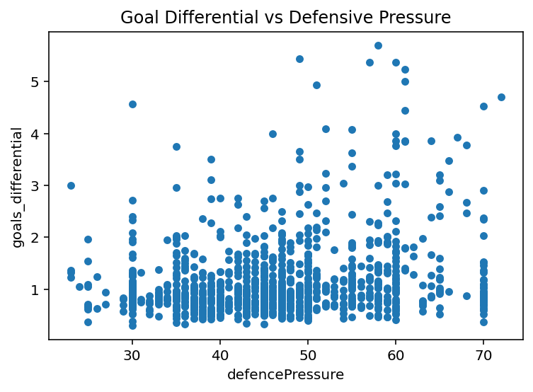

```python
numeric_col = 'defencePressure'
def plot_numeric() :
    df[[numeric_col, factor]].plot(x=numeric_col, y=factor, kind='scatter', title=ylab + ' vs Defensive Pressure');
plot_numeric()
```

I also found that defensivePressure seemed to have a correlation with goal differential. Here I show a scatterplot, which shows a very weak correlation.

Note: I made the boxplot and scatterplot into functions because I would re-use code for the next research quesition.

### Research Question 2 Which factors correlate with win percentage?

Here I performed the same analysis on win percentage. It turns out that goal differential and win percentage have the same factors that correlate with it.

```python
# Continue to explore the data to address your additional research
#   questions. Add more headers as needed if you have more questions to
#   investigate.
corr_mat[['win_pct']].sort_values(by=['win_pct'], ascending=False).iloc[np.r_[0:5, -5:0]]
```

|  | win_pct |
| --- | --- |
| chanceCreationPositioningClass_Free Form | 0.259520 |
| buildUpPlayPositioningClass_Free Form | 0.219810 |
| defencePressure | 0.217931 |
| chanceCreationShootingClass_Lots | 0.164205 |
| buildUpPlayPassingClass_Short | 0.145931 |
| chanceCreationPassingClass_Normal | -0.075576 |
| buildUpPlayPassingClass_Long | -0.100266 |
| chanceCreationShootingClass_Normal | -0.174070 |
| buildUpPlayPositioningClass_Organised | -0.219810 |
| chanceCreationPositioningClass_Organised | -0.259520 |

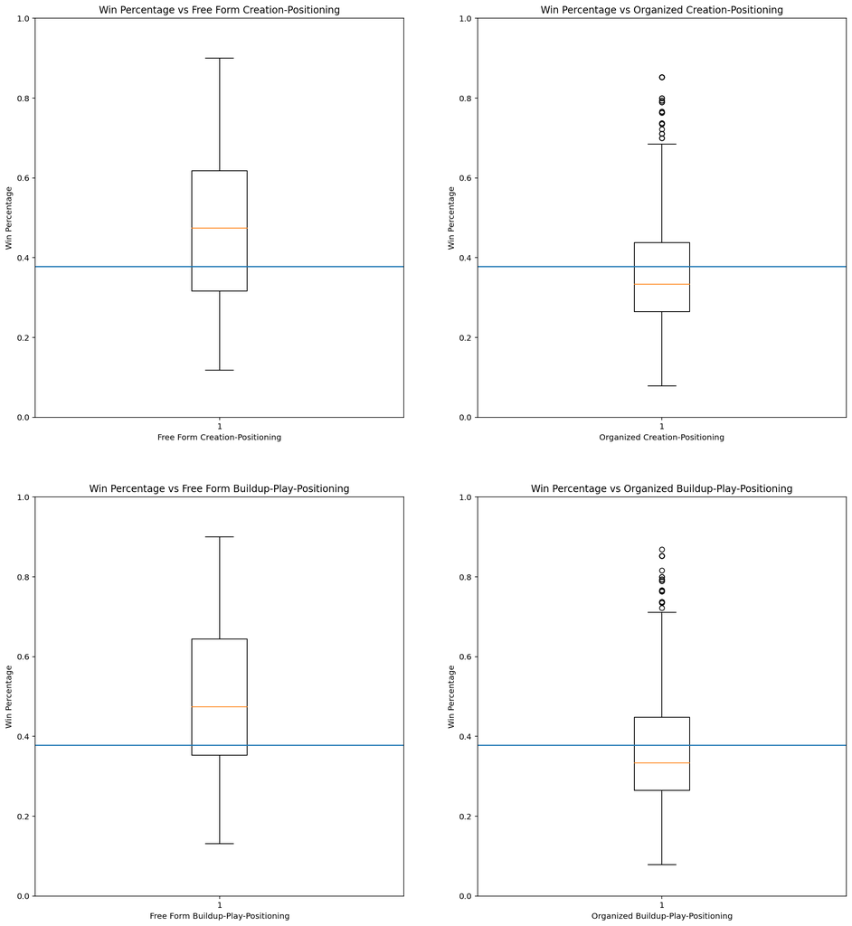

```python
factor = 'win_pct'
ylab = 'Win Percentage'
ylim = 1
boxplot_()
```

As indicated by the 4 boxplots for free-form for both creation-position and build-up position was mostly above the blue line which was the mean win percentage.

On the other hand, the distribution for organized for both creation-position and build-up position was mostly below the blue line which was the mean win percentage.

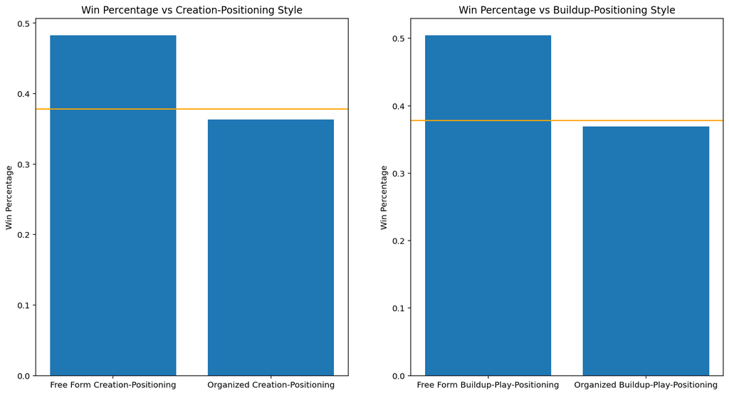

```python
barplot_()
```

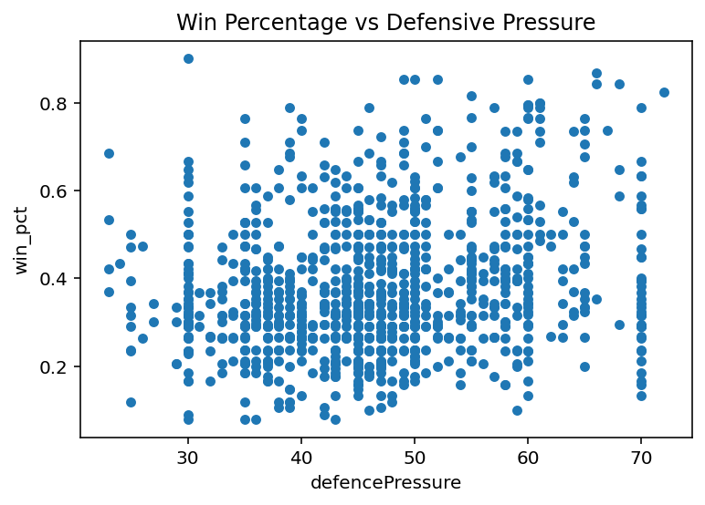

```python
plot_numeric()
```

I also found that defensivePressure seemed to have a correlation with win percentage. Here I show a scatterplot, which shows a very weak correlation.

### Note on Research Question 1 and 2

As we can see from the box plots and bar plots for creation-postioning and building-position there is a correlation between free form and better win percentage/goal differential. However, we saw that neither of these correlation coffecients were actually very high. All were below 0.3, meaning we cannot say for sure whether these metrics had a significant impact on goal differential or win percentage.

This can also said about defensive pressure. The 2 scatterplots barely showed any correlation between defensive pressure and win percentage/goal differential.

Basically, correlation does not mean causation. There are many factors that affect goal differential and win percentage, meaning there are many confounding variables.

One thing I did want to see was how common teams had free form vs organized.

```python
cols = ['chanceCreationPositioningClass_Free Form', 'chanceCreationPositioningClass_Organised',
        'buildUpPlayPositioningClass_Free Form', 'buildUpPlayPositioningClass_Organised']
labels = ['Free Form Creation-Positioning', 'Organized Creation-Positioning',
          'Free Form Buildup-Play-Positioning', 'Organized Buildup-Play-Positioning']

for i in range(4) :
    x = df[df[ cols[i] ] == 1].shape[0]
    print('Number of ' + labels[i] + ': ' + str(x))
```

```
Number of Free Form Creation-Positioning: 133
Number of Organized Creation-Positioning: 907
Number of Free Form Buildup-Play-Positioning: 70
Number of Organized Buildup-Play-Positioning: 970
```

As we can see only a small percentage of teams do Free-Form Creation-Position and an even smaller percentage of teams do Free Form Buildup-Positioning. Because there is such a small sample size of people doing free-form it is hard to draw any conclusions. There could be confounding variables.

### Research Question 3: Which teams were the best overall (season, team)?

```python
df.sort_values(by='win_pct', ascending=False).head()
```

|  | team | date | goals_differential | win_pct | loss_pct | ties_pct | buildUpPlaySpeed | buildUpPlayPassing | chanceCreationPassing | chanceCreationCrossing | ... | defencePressureClass_High | defencePressureClass_Medium | defenceAggressionClass_Contain | defenceAggressionClass_Double | defenceAggressionClass_Press | defenceTeamWidthClass_Narrow | defenceTeamWidthClass_Normal | defenceTeamWidthClass_Wide | defenceDefenderLineClass_Cover | defenceDefenderLineClass_Offside Trap |
| --- | --- | --- | --- | --- | --- | --- | --- | --- | --- | --- | --- | --- | --- | --- | --- | --- | --- | --- | --- | --- | --- |
| 295 | FC Porto | 2010 | 4.562500 | 0.900000 | 0.000000 | 0.100000 | 30.0 | 30.0 | 60.0 | 60.0 | ... | 0 | 0 | 1 | 0 | 0 | 1 | 0 | 0 | 0 | 1 |
| 460 | Juventus | 2013 | 3.478261 | 0.868421 | 0.052632 | 0.078947 | 39.0 | 33.0 | 51.0 | 63.0 | ... | 0 | 1 | 0 | 1 | 0 | 0 | 1 | 0 | 1 | 0 |
| 260 | FC Bayern Munich | 2012 | 5.444444 | 0.852941 | 0.029412 | 0.117647 | 47.0 | 40.0 | 34.0 | 31.0 | ... | 0 | 1 | 0 | 0 | 1 | 0 | 1 | 0 | 1 | 0 |
| 651 | PSV | 2014 | 2.967742 | 0.852941 | 0.117647 | 0.029412 | 67.0 | 40.0 | 53.0 | 53.0 | ... | 0 | 1 | 0 | 0 | 1 | 0 | 1 | 0 | 1 | 0 |
| 261 | FC Bayern Munich | 2013 | 4.086957 | 0.852941 | 0.058824 | 0.088235 | 56.0 | 41.0 | 40.0 | 44.0 | ... | 0 | 1 | 0 | 0 | 1 | 0 | 1 | 0 | 1 | 0 |

5 rows × 47 columns

```python
df.sort_values(by='win_pct').head()
```

|  | team | date | goals_differential | win_pct | loss_pct | ties_pct | buildUpPlaySpeed | buildUpPlayPassing | chanceCreationPassing | chanceCreationCrossing | ... | defencePressureClass_High | defencePressureClass_Medium | defenceAggressionClass_Contain | defenceAggressionClass_Double | defenceAggressionClass_Press | defenceTeamWidthClass_Narrow | defenceTeamWidthClass_Normal | defenceTeamWidthClass_Wide | defenceDefenderLineClass_Cover | defenceDefenderLineClass_Offside Trap |
| --- | --- | --- | --- | --- | --- | --- | --- | --- | --- | --- | --- | --- | --- | --- | --- | --- | --- | --- | --- | --- | --- |
| 202 | Córdoba CF | 2014 | 0.323529 | 0.078947 | 0.631579 | 0.289474 | 40.0 | 53.0 | 40.0 | 66.0 | ... | 0 | 1 | 0 | 0 | 1 | 0 | 1 | 0 | 1 | 0 |
| 79 | Aston Villa | 2015 | 0.355263 | 0.078947 | 0.710526 | 0.210526 | 63.0 | 54.0 | 60.0 | 48.0 | ... | 0 | 1 | 0 | 0 | 1 | 0 | 1 | 0 | 1 | 0 |
| 213 | ES Troyes AC | 2015 | 0.337349 | 0.078947 | 0.684211 | 0.236842 | 49.0 | 51.0 | 52.0 | 49.0 | ... | 0 | 1 | 0 | 0 | 1 | 0 | 1 | 0 | 1 | 0 |
| 19 | AC Arles-Avignon | 2010 | 0.300000 | 0.078947 | 0.631579 | 0.289474 | 50.0 | 65.0 | 30.0 | 35.0 | ... | 0 | 0 | 0 | 0 | 1 | 0 | 1 | 0 | 1 | 0 |
| 1015 | Willem II | 2010 | 0.377551 | 0.088235 | 0.735294 | 0.176471 | 35.0 | 30.0 | 30.0 | 40.0 | ... | 0 | 0 | 1 | 0 | 0 | 1 | 0 | 0 | 1 | 0 |

5 rows × 47 columns

### Research Question 4: Which teams have been the best and worst consistently?

```python
df_agg = df[['team', 'win_pct']].groupby(by=['team']).agg(['mean', 'count'])
df_agg.columns = ['win_pct', 'count']
df_agg['team'] = df_agg.index.get_level_values('team')
df_agg.reset_index(drop=True, inplace=True)
df_agg = df_agg.query("count > 4")
```

I show the table form of the best teams and their average win percentage.

```python
best_team_df = df_agg.sort_values(by='win_pct', ascending=False).head()
best_team_df
```

|  | win_pct | count | team |
| --- | --- | --- | --- |
| 70 | 0.771930 | 6 | FC Barcelona |
| 206 | 0.763399 | 6 | SL Benfica |
| 186 | 0.754386 | 6 | Real Madrid CF |
| 81 | 0.751961 | 6 | FC Porto |
| 72 | 0.750000 | 6 | FC Bayern Munich |

I show the table form of the worst teams and their average win percentage.

```python
worst_team_df = df_agg.sort_values(by='win_pct').head()
worst_team_df
```

|  | win_pct | count | team |
| --- | --- | --- | --- |
| 14 | 0.205229 | 6 | Académica de Coimbra |
| 19 | 0.228070 | 6 | Aston Villa |
| 223 | 0.236842 | 5 | St. Mirren |
| 247 | 0.247059 | 6 | Vitória Setúbal |
| 229 | 0.254386 | 6 | Sunderland |

Here is a graphical view of the best and worst teams in one plot.

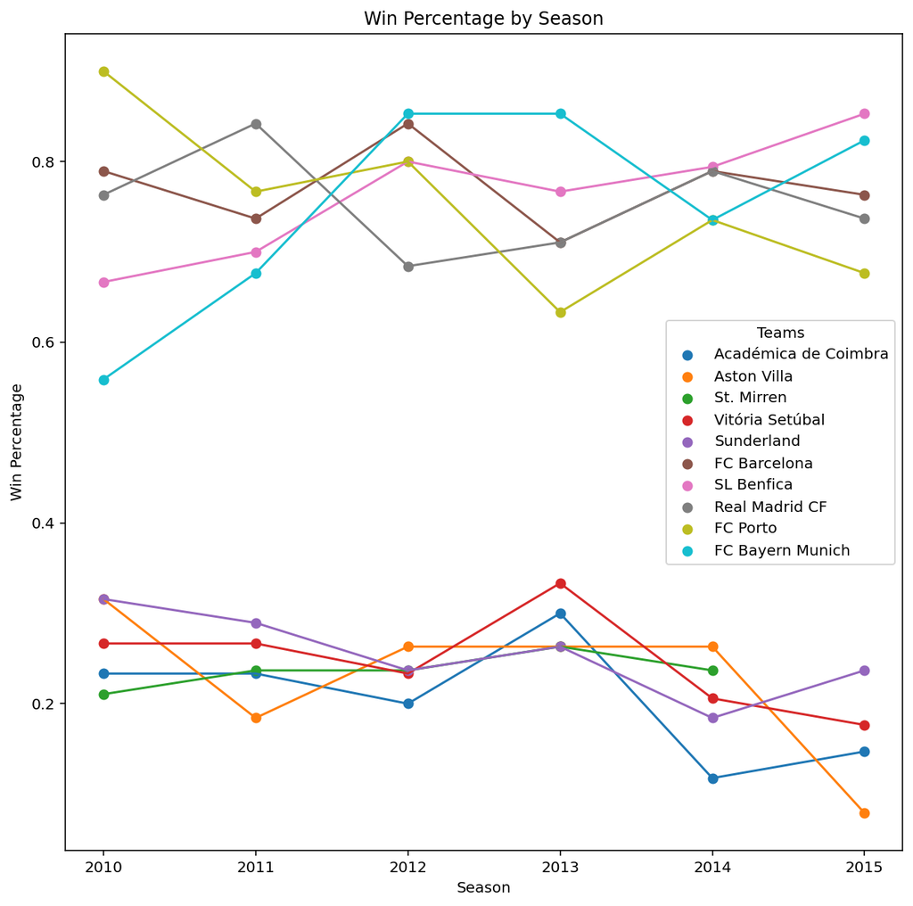

```python
best_teams, worst_teams = best_team_df.team.tolist(), worst_team_df.team.tolist()
df['date'] = df['date'].astype(int)
plt.figure(figsize=(10, 10))
for team in worst_teams :
    temp = df[df['team'] == team]
    plt.scatter(temp['date'], temp['win_pct'], label=team);
    plt.plot(temp['date'], temp['win_pct']);


for team in best_teams :
    temp = df[df['team'] == team]
    plt.scatter(temp['date'], temp['win_pct'], label=team);
    plt.plot(temp['date'], temp['win_pct']);

plt.legend(title='Teams');
plt.xlabel('Season');
plt.ylabel('Win Percentage');
plt.title('Win Percentage by Season');
```

## Conclusions

My first question I asked were which factors affected goal differential the most. I began by doing the correlation matrix. Using a correlation matrix which took the Pearson’s Constant, I found that 3 factors (Free Form Creation Positioning, Free Form Buildup Positioning, and defensive pressure) had a weak positive correlation of 0.2+. I also saw that there were 2 factors (Organized Creation Positioning and Organized Buildup Positioning) had a weak negative correlation of 0.2+. I visualized those 5 factors using box-plots and scatterplot.

The second question I asked was which factors affected win percentage the most. Uninterestingly I found those same 3 factors with a weak positive correlation and same 2 factors with a weak negative correlation and did very similar visualizations.

In the end, I concluded that the type of positioning had the most correlation with goal differential and win percentage. Free form is supposedly better and organized is worse. Defensive pressure is also correlated with both. However, the reason why these results are not conclusive because all 3 are weak correlations and correlation does not equal causation. Furthermore, we can see from the 'Note on Research Question 1 and 2’ section that most teams use Organized Creation-Positioning so the sample sizes are skewed.

The third question I asked was which teams were the best overall (team, season). The top 5 best performances were the 2010 FC Porto, 2013 Juventus, 2012 FC Bayern Munich, 2014 PSV and FC Bayern Munich. The bottom 5 worst performances were 2014 Córdoba CF, 2015 Aston Villa, 2015 ES Troyes AC, 2010 AC Arles-Avignon, and 2010 Willem II. These ranks were generated purely by win percentage.

Not for all all 4 research questions these were conducted between the timeline of 2010-2016.

```python
from subprocess import call
call(['python', '-m', 'nbconvert', 'Investigate_a_Dataset.ipynb'])
```

```
1
```